# Lake Water Quality Analysis

Matthew Ross

9/17/2019

# LAGOS Analysis

## Loading in data

### First download and then specifically grab the locus (or site lat longs)

```r
#Lagos download script
#lagosne_get(dest_folder = LAGOSNE:::lagos_path(),overwrite=T)

#Load in lagos
lagos <- lagosne_load()
#Grab the lake centroid info
lake_centers <- lagos$locus

# Make an sf object
spatial_lakes <- st_as_sf(lake_centers,coords=c('nhd_long','nhd_lat'),
                          crs=4326)

#Grab the water quality data
nutr <- lagos$epi_nutr

#Look at column names
#names(nutr)
```

### Subset columns nutr to only keep key info that we want

```r
clarity_only <- nutr %>%
  select(lagoslakeid,sampledate,chla,doc,secchi) %>%
  mutate(sampledate = as.character(sampledate) %>% ymd(.))
```

### Keep sites with at least 200 observations

```r
#Look at the number of rows of dataset
#nrow(clarity_only)

chla_secchi <- clarity_only %>%
  filter(!is.na(chla),
         !is.na(secchi))

# How many observatiosn did we lose?
# nrow(clarity_only) - nrow(chla_secchi)


# Keep only the lakes with at least 200 observations of secchi and chla
chla_secchi_200 <- chla_secchi %>%
  group_by(lagoslakeid) %>%
  mutate(count = n()) %>%
  filter(count > 200)
```

### Join water quality data to spatial data

```r
spatial_200 <- inner_join(spatial_lakes,chla_secchi_200 %>%
                            distinct(lagoslakeid,.keep_all=T),
                          by='lagoslakeid')
```

### Mean Chl_a map

```r
### Take the mean chl_a and secchi by lake

mean_values_200 <- chla_secchi_200 %>%
  # Take summary by lake id
  group_by(lagoslakeid) %>%
  # take mean chl_a per lake id
  summarize(mean_chl = mean(chla,na.rm=T),
            mean_secchi=mean(secchi,na.rm=T)) %>%
  #Get rid of NAs
  filter(!is.na(mean_chl),
         !is.na(mean_secchi)) %>%
  # Take the log base 10 of the mean_chl
  mutate(log10_mean_chl = log10(mean_chl))

#Join datasets
mean_spatial <- inner_join(spatial_lakes,mean_values_200,
                          by='lagoslakeid')

#Make a map
mapview(mean_spatial,zcol='log10_mean_chl')
```

[interactive chart not shown]

# Class work

## 1) What is the correlation between Secchi Disk Depth and Chlorophyll a for

sites with at least 200 observations?

- Here, I just want a plot of chla vs secchi for all sites

### My answer:

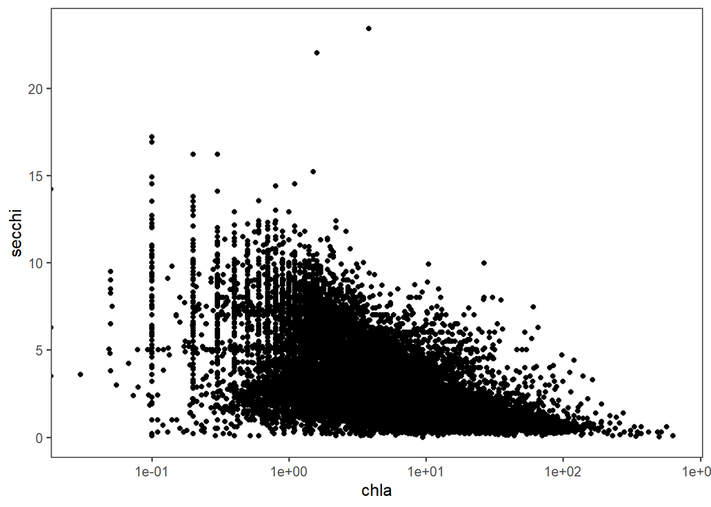

```r
ggplot(chla_secchi_200,aes(x=chla,y=secchi)) +
  geom_point() +
  theme_few() +
  scale_x_log10()
```

### Your answers:

Here someone took the average correlation, which also works to illustrate the point that increased algal biomass lowers lake clarity.

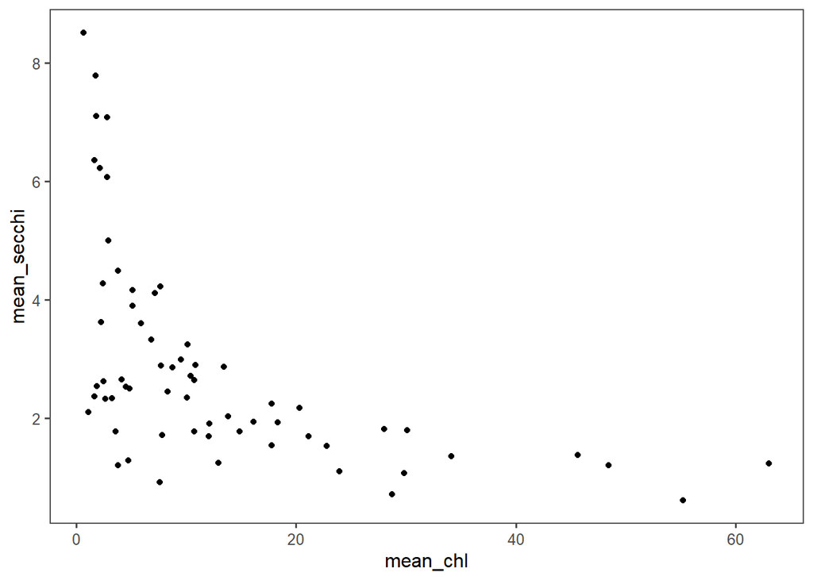

```r
ggplot(mean_spatial, aes(x = mean_chl, y = mean_secchi))+
  geom_point()
```

## 2) What states have the most data? (I should have clarified I meant clarity

only data)

### 2a) First you will need to make a lagos spatial dataset that has the total

number of counts per site.

### My answer:

```r
clarity_counts <- clarity_only %>%
  group_by(lagoslakeid) %>%
  summarize(count=n())

spatial_counts <- inner_join(spatial_lakes,clarity_counts,by='lagoslakeid')
```

### Your answers:

```r
count_nutr <- nutr %>%
  group_by(lagoslakeid) %>%
  summarise(count = n())

#Here the distinct call is unnecessary since summarize already keeps only
#unique lagoslakeids
spatial_nutr <- inner_join(spatial_lakes,count_nutr %>%
                            distinct(lagoslakeid,.keep_all=T),
                          by='lagoslakeid')
```

### 2b) Second, you will need to join this point dataset to the us_boundaries

data.

### My answer (and most of you as well)

```r
states <- us_states()
state_counts <- st_join(states, spatial_counts)
```

```
## although coordinates are longitude/latitude, st_intersects assumes that they are planar
```

### 2c) Then you will want to group by state and sum all the observations in that

state and arrange that data from most to least total observations per state.

### My answer (and most of you)

```r
state_summary <- state_counts %>%
  group_by(name) %>%
  summarize(state_obs = sum(count))


state_summary %>%
  arrange(-state_obs)
```

```
## Simple feature collection with 52 features and 2 fields
## geometry type:  MULTIPOLYGON
## dimension:      XY
## bbox:           xmin: -179.1743 ymin: 17.91377 xmax: 179.7739 ymax: 71.35256
## epsg (SRID):    4326
## proj4string:    +proj=longlat +datum=WGS84 +no_defs
## # A tibble: 52 x 3
##    name       state_obs                                            geometry
##    <chr>          <int>                                  <MULTIPOLYGON [°]>
##  1 Minnesota     358137 (((-97.22904 49.00069, -96.93096 48.99998, -96.405~
##  2 Wisconsin     145910 (((-86.93428 45.42115, -86.83575 45.45019, -86.805~
##  3 Michigan      100683 (((-84.61622 45.89447, -84.51789 45.82854, -84.419~
##  4 Maine          87380 (((-68.92401 43.88541, -68.87478 43.90471, -68.849~
##  5 New York       35754 (((-72.01893 41.27411, -71.9268 41.29012, -71.9172~
##  6 Vermont        24794 (((-73.41632 44.09942, -73.39987 44.15249, -73.395~
##  7 Rhode Isl~     22882 (((-71.63147 41.16668, -71.59334 41.23743, -71.545~
##  8 Missouri       12318 (((-95.76564 40.58521, -95.53318 40.58225, -95.373~
##  9 New Hamps~     11220 (((-72.55611 42.86625, -72.53147 42.89795, -72.532~
## 10 Illinois        3143 (((-91.50617 40.20064, -91.49696 40.2487, -91.4928~
## # ... with 42 more rows
```

##3 Is there a spatial pattern in Secchi disk depth for lakes with at least 200 observations?

### My answer

```r
## Your code here
mapview(spatial_200,zcol = 'secchi')
```

[interactive chart not shown]